# Processing data for plotting across the antimeridian with vector data

## 3 Exact splitting at the antimeridian

When geometric continuity matters — for contour lines, coastlines loaded from external sources, or range polygons — you can compute the latitude at which the segment crosses $\lambda_0 \pm 180°$ and split the segment there, inserting two correctly-terminated endpoints at the boundary. The crossing latitude follows from linear interpolation along the segment:

$$\lambda_{\text{cross}} = \lambda_0 + 180° \cdot \operatorname{sign}(\Delta\lambda)$$
$$\phi_{\text{cross}} = \phi_1 + (\phi_2 - \phi_1)\,\frac{\lambda_{\text{cross}} - \lambda_1}{\lambda_2 - \lambda_1}$$

where $\Delta\lambda = \lambda_2 - \lambda_1$ is the longitude gap after normalization, and $\phi_1, \phi_2$ are the endpoint latitudes.

```julia
"""
    split_at_antimeridian(lons, lats; lon_0=0.0)

Split a linestring at every antimeridian crossing, returning a
`Vector` of `(lons, lats)` segment tuples, each free of crossings.
Endpoints of adjacent segments share the exact crossing latitude.
"""
function split_at_antimeridian(lons, lats; lon_0=0.0)
    lons_n   = normalize_lon.(lons, lon_0)
    segments = Tuple{Vector{Float64}, Vector{Float64}}[]
    seg_lons = [lons_n[1]]
    seg_lats = [lats[1]]
    for i in 1:(length(lons_n) - 1)
        Δλ = lons_n[i+1] - lons_n[i]
        if abs(Δλ) > 180.0
            λ_cross = lon_0 + 180.0 * sign(Δλ)
            t       = (λ_cross - lons_n[i]) / Δλ
            ϕ_cross = lats[i] + t * (lats[i+1] - lats[i])
            push!(seg_lons, λ_cross)
            push!(seg_lats, ϕ_cross)
            push!(segments, (copy(seg_lons), copy(seg_lats)))
            seg_lons = [λ_cross - 360.0 * sign(Δλ)]
            seg_lats = [ϕ_cross]
        end
        push!(seg_lons, lons_n[i+1])
        push!(seg_lats, lats[i+1])
    end
    push!(segments, (seg_lons, seg_lats))
    return segments
end
```

**1**

Accumulate completed segments as a vector of `(lons, lats)` pairs; each returned segment is free of antimeridian crossings.

**2**

A normalized gap larger than $180°$ signals a crossing, as in `antimeridian_breaks`.

**3**

The crossing longitude is at the boundary of the current window: $\lambda_0 + 180°$ or $\lambda_0 - 180°$ depending on direction of travel.

**4**

Linear interpolation along the segment gives the exact crossing latitude $\phi_\text{cross}$.

**5**

Close the current segment at the crossing point and store it.

**6**

Open the new segment on the *other* side of the boundary: shift by $\pm360°$ so the continuation is correctly positioned in the normalized window.

**7**

Append the final (possibly unclosed) segment after the loop.

```
Main.Notebook.split_at_antimeridian
```

```julia
lon_0    = 180.0
segments = split_at_antimeridian(lons_track, lats_track; lon_0)

fig = Figure()
ax  = GeoAxis(fig[1, 1]; dest="+proj=eqearth +lon_0=$(lon_0)")
lines!(ax, GeoMakie.coastlines(ax))
for (sl, sp) in segments
    lines!(ax, sl, sp; color=:steelblue, linewidth=2)
    scatter!(ax, sl, sp; color=:steelblue)
end
fig
```

**1**

Returns a `Vector` of segment pairs; each segment terminates precisely at the antimeridian boundary.

**2**

Plot each segment independently; adjacent segments share a boundary endpoint, so the track appears visually continuous with no gap at the antimeridian.

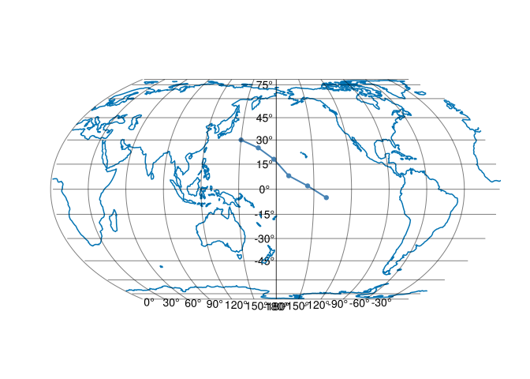

**TipPolygon data and `GeometryOps.jl`**

For *polygon* geometries — species range polygons, biome boundaries, ocean basins — antimeridian splitting is considerably more involved: a polygon that crosses the boundary must be *cut* into two closed polygons, each with a shared edge running along the antimeridian. Implementing this correctly requires handling winding order, hole geometries, and coordinate ring closure.

Rather than implementing this manually, use [`GeometryOps.jl`](https://github.com/JuliaGeo/GeometryOps.jl), which provides a `fix` function with an `antimeridian_correction` pass that handles both linestring and polygon geometries via `GeoInterface.jl`-compatible objects:

```julia
using GeometryOps, GeoInterface

geom_fixed = GeometryOps.fix(geom; corrections=[GeometryOps.AntimeridianCorrection()])
```

The corrected geometry can then be passed directly to `poly!` or `lines!` on a `GeoAxis` without further coordinate manipulation.

Back to top